# Lateral Hand Acceleration: Exploratory Analysis

- Show All Code
- Hide All Code
- View Source

STAT 470W capstone | Original EDA and expanded response checks

## Purpose and interpretation

This report contains the analyses from `01_exploratory_analysis.R` and adds checks needed before estimating lateral response onset. Repeated versions of the same plot are consolidated. The original R script is unchanged; this report is self-contained and reads the trial CSV files directly.

The project README specifies 1,000 Hz sampling, acceleration obtained by differentiating lateral hand position twice, and a response-search window from the **Pixel event to Got target or Missed target**. An extended plotting window provides context but does not extend the response-search window. Both hit and miss trials are retained when their events and signals are valid.

**Important**

The filename-to-response mapping still needs confirmation from the data owner. The proposed mapping is LeftBackground = left, RightBackground = right, and StaticBackground = none. The proposed coordinate signs are left = -1 and right = +1. EDA runs without confirming these assumptions. The onset-method section runs only when `mapping_confirmed: true` is set after confirming both the labels and signs. Inspect Conditions A/B separately; their meaning is not inferred here.

The default uses **unsmoothed, position-derived acceleration**. The smoothing sensitivity section compares alternative centered windows without selecting a preferred window from the results. Change `smoothing_ms` only with a documented reason: smoothing can change peak shape, threshold crossings, and onset.

## Setup and reusable functions

## File inventory and trial metadata

This replaces original Sections 1–3, 8–9, and 13. Trial IDs use the full path, because trial numbers repeat across participants, conditions, and blocks.

```r
trial_files <- sort(list.files(data_dir, pattern = "\\.csv$", recursive = TRUE,
                              full.names = TRUE, ignore.case = TRUE))
if (!length(trial_files)) stop("No trial CSV files found.")
trial_info <- tibble(File = trial_files) |>
  mutate(
    Trial_ID = File,
    Participant = str_extract(File, "Participant [AB]"),
    Block_Folder = basename(dirname(File)),
    Condition = str_extract(Block_Folder, "(?<=Condition_)[AB]"),
    Block = as.integer(str_extract(Block_Folder, "(?<=Block_)\\d+")),
    Trial = as.integer(str_extract(basename(File), "(?<=Trial)\\d+")),
    Background = str_extract(basename(File), "LeftBackground|RightBackground|StaticBackground"),
    Target_Speed = str_extract(basename(File), "FastTarget|SlowTarget")
  )
if (anyNA(trial_info[c("Participant", "Condition", "Block", "Trial", "Background", "Target_Speed")])) {
  stop("Some filenames could not be mapped to metadata; inspect trial_info.")
}
show_table(trial_info |> select(-Trial_ID) |> head(10))
```

| File | Participant | Block_Folder | Condition | Block | Trial | Background | Target_Speed |
| --- | --- | --- | --- | --- | --- | --- | --- |
| data/Participant A/Condition_A_Block_1/Trial1.StaticBackgroundSlowTarget.csv | Participant A | Condition_A_Block_1 | A | 1 | 1 | StaticBackground | SlowTarget |
| data/Participant A/Condition_A_Block_1/Trial10.StaticBackgroundSlowTarget.csv | Participant A | Condition_A_Block_1 | A | 1 | 10 | StaticBackground | SlowTarget |
| data/Participant A/Condition_A_Block_1/Trial100.LeftBackgroundFastTarget.csv | Participant A | Condition_A_Block_1 | A | 1 | 100 | LeftBackground | FastTarget |
| data/Participant A/Condition_A_Block_1/Trial11.RightBackgroundSlowTarget.csv | Participant A | Condition_A_Block_1 | A | 1 | 11 | RightBackground | SlowTarget |
| data/Participant A/Condition_A_Block_1/Trial12.LeftBackgroundSlowTarget.csv | Participant A | Condition_A_Block_1 | A | 1 | 12 | LeftBackground | SlowTarget |
| data/Participant A/Condition_A_Block_1/Trial13.LeftBackgroundSlowTarget.csv | Participant A | Condition_A_Block_1 | A | 1 | 13 | LeftBackground | SlowTarget |
| data/Participant A/Condition_A_Block_1/Trial14.RightBackgroundSlowTarget.csv | Participant A | Condition_A_Block_1 | A | 1 | 14 | RightBackground | SlowTarget |
| data/Participant A/Condition_A_Block_1/Trial15.RightBackgroundSlowTarget.csv | Participant A | Condition_A_Block_1 | A | 1 | 15 | RightBackground | SlowTarget |
| data/Participant A/Condition_A_Block_1/Trial16.StaticBackgroundFastTarget.csv | Participant A | Condition_A_Block_1 | A | 1 | 16 | StaticBackground | FastTarget |
| data/Participant A/Condition_A_Block_1/Trial17.LeftBackgroundFastTarget.csv | Participant A | Condition_A_Block_1 | A | 1 | 17 | LeftBackground | FastTarget |

```r
show_table(trial_info |> count(Participant, Condition, Block, name = "Trials"))
```

| Participant | Condition | Block | Trials |
| --- | --- | --- | --- |
| Participant A | A | 1 | 100 |
| Participant A | A | 2 | 100 |
| Participant A | A | 3 | 100 |
| Participant A | B | 1 | 100 |
| Participant A | B | 2 | 100 |
| Participant A | B | 3 | 100 |
| Participant B | A | 1 | 100 |
| Participant B | A | 2 | 100 |
| Participant B | A | 3 | 100 |
| Participant B | B | 1 | 100 |
| Participant B | B | 2 | 100 |
| Participant B | B | 3 | 100 |

```r
show_table(trial_info |> count(Background, Target_Speed, name = "Trials"))
```

| Background | Target_Speed | Trials |
| --- | --- | --- |
| LeftBackground | FastTarget | 180 |
| LeftBackground | SlowTarget | 180 |
| RightBackground | FastTarget | 180 |
| RightBackground | SlowTarget | 180 |
| StaticBackground | FastTarget | 240 |
| StaticBackground | SlowTarget | 240 |

```r
show_table(trial_info |> count(Participant, Condition, Block, Trial) |> filter(n > 1))
```

| Participant | Condition | Block | Trial | n |
| --- | --- | --- | --- | --- |

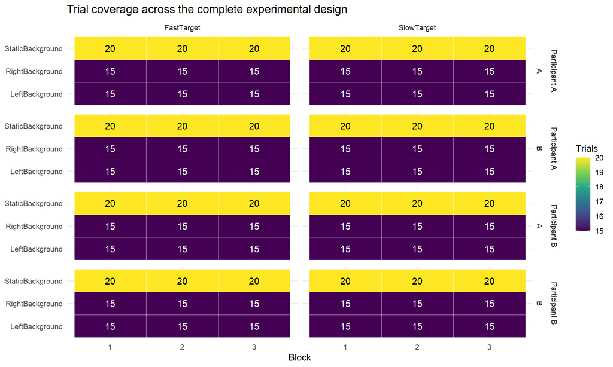

```r
cell_counts <- trial_info |> count(Participant, Condition, Block, Background, Target_Speed) |>
  complete(Participant, Condition, Block, Background, Target_Speed, fill = list(n = 0))
ggplot(cell_counts, aes(factor(Block), Background, fill = n)) +
  geom_tile(color = "white") + geom_text(aes(label = n, color = n < 18)) +
  scale_color_manual(values = c(`TRUE` = "white", `FALSE` = "black"), guide = "none") +
  facet_grid(Participant + Condition ~ Target_Speed) +
  scale_fill_viridis_c() + labs(x = "Block", y = NULL, fill = "Trials",
    title = "Trial coverage across the complete experimental design")
```

```r
save_table(trial_info, "trial_metadata.csv")
```

## Import, event validation, and position-derived signals

Each file is read once for the main analysis. Checks use the full recording before cropping. A trial must have one numeric Pixel event, exactly one numeric hit or miss event, consecutive integer frames at 1 ms intervals, and complete position-derived acceleration throughout its response window to enter the expanded response analyses. Failed imports and invalid trials stay in the audit.

Centered differences use actual frame times in **seconds**. They leave missing values at derivative boundaries rather than extrapolating. Optional centered smoothing is applied to position before differentiation. The full recording is processed before the plotting window is selected.

```r
read_trial <- function(file) {
  raw <- read_csv(file, col_types = cols(.default = col_character()),
                  show_col_types = FALSE, progress = FALSE)
  missing_columns <- setdiff(c(signal_columns, event_columns), names(raw))
  if (length(missing_columns)) stop(paste("Missing columns:", paste(missing_columns, collapse = ", ")))
  d <- raw |> mutate(across(all_of(signal_columns), ~ suppressWarnings(as.numeric(.x))))
  pixel <- one_event(raw$`Pixel event`)
  hit <- event_values(raw$`Got target`)
  miss <- event_values(raw$`Missed target`)
  outcome <- case_when(length(hit) > 0 & length(miss) > 0 ~ "Both recorded",
    length(hit) > 0 ~ "Hit", length(miss) > 0 ~ "Miss", TRUE ~ "No outcome recorded")
  ending <- c(hit, miss)
  end_frame <- if (length(ending) == 1 && is.finite(ending)) ending else NA_real_
  frame_ok <- nrow(d) >= 5 && all(is.finite(d$Frame)) &&
    all(d$Frame == round(d$Frame)) && all(diff(d$Frame) == 1)
  events_ok <- is.finite(pixel) && is.finite(end_frame) && end_frame > pixel &&
    pixel %in% d$Frame && end_frame %in% d$Frame
  d <- d |> mutate(
    Time_ms = Frame - pixel,
    Time_s = Frame / fs,
    Position_smoothed = center_mean(Right_HandX, smooth_n),
    Velocity_from_position = differentiate(Position_smoothed, Time_s),
    Acceleration_from_position = differentiate(Velocity_from_position, Time_s),
    Velocity_raw_position = differentiate(Right_HandX, Time_s),
    Acceleration_raw_position = differentiate(Velocity_raw_position, Time_s),
    Acceleration_from_velocity = differentiate(Right_HandVelX, Time_s),
    In_response = events_ok & Frame >= pixel & Frame <= end_frame
  )
  response <- d |> filter(In_response)
  signal_ok <- nrow(response) >= 3 && all(is.finite(response$Acceleration_from_position))
  reasons <- c(if (!frame_ok) "Invalid frame sequence",
    if (!events_ok) "Invalid or missing event window",
    if (events_ok && !signal_ok) "Incomplete derived response signal")
  numeric_parse_failures <- sum(vapply(signal_columns, function(nm) {
    text <- raw[[nm]]
    sum(!is.na(text) & nzchar(trimws(text)) & !is.finite(d[[nm]]))
  }, numeric(1)))
  audit <- tibble(
    Trial_ID = file, Import_OK = TRUE, Import_error = NA_character_,
    Rows = nrow(d), Pixel_entries = length(event_values(raw$`Pixel event`)),
    Hit_entries = length(hit), Miss_entries = length(miss), Outcome = outcome,
    Pixel_frame = pixel, End_frame = end_frame, End_ms = end_frame - pixel,
    Frame_OK = frame_ok, Events_OK = events_ok, Signal_OK = signal_ok,
    Duplicate_frames = sum(duplicated(d$Frame)),
    Frame_gaps = sum(diff(d$Frame) > 1, na.rm = TRUE),
    Nonincreasing_steps = sum(diff(d$Frame) <= 0, na.rm = TRUE),
    Numeric_parse_failures = numeric_parse_failures,
    Missing_position = sum(!is.finite(d$Right_HandX)),
    Missing_recorded_acceleration = sum(!is.finite(d$Right_HandAccX)),
    Baseline_samples = sum(d$Time_ms >= baseline_limits[1] & d$Time_ms <= baseline_limits[2] &
                            is.finite(d$Acceleration_from_position), na.rm = TRUE),
    Plot_start_available = any(d$Time_ms == plot_limits[1], na.rm = TRUE),
    Plot_end_available = any(d$Time_ms == plot_limits[2], na.rm = TRUE),
    Eligible = frame_ok && events_ok && signal_ok,
    Exclusion_reason = if (length(reasons)) paste(reasons, collapse = "; ") else "Retained"
  )
  keep_end <- max(500, end_frame - pixel + 300, na.rm = TRUE)
  list(audit = audit, data = d |> filter(Time_ms >= -300, Time_ms <= keep_end),
       events = raw |> select(Frame, all_of(event_columns)) |> head(10))
}
safe_read_trial <- function(file) {
  tryCatch(read_trial(file), error = function(e) list(
    audit = tibble(Trial_ID = file, Import_OK = FALSE, Import_error = conditionMessage(e),
      Eligible = FALSE, Exclusion_reason = "Import failed"),
    data = tibble(), events = tibble()))
}
```

```r
imports <- map(trial_info$File, safe_read_trial)
trial_audit <- trial_info |> left_join(map_dfr(imports, "audit"), by = "Trial_ID")
all_data <- map2_dfr(imports, trial_info$Trial_ID, function(x, id) {
  if (!nrow(x$data)) return(tibble())
  mutate(x$data, Trial_ID = id)
})
if (!nrow(all_data)) stop("No trial signals were imported; inspect the CSV schemas.")
all_data <- all_data |>
  left_join(trial_audit |> select(Trial_ID, Participant, Condition, Block, Trial,
    Background, Target_Speed, Outcome, End_ms, Eligible), by = "Trial_ID")
sample_index <- which(map_lgl(imports, ~ nrow(.x$data) > 0))[1]
sample_id <- trial_info$Trial_ID[sample_index]
sample_trial <- all_data |> filter(Trial_ID == sample_id)
sample_metadata <- trial_audit |> filter(Trial_ID == sample_id)
sample_label <- paste(sample_metadata$Participant, paste("Condition", sample_metadata$Condition),
  paste("Block", sample_metadata$Block), paste("Trial", sample_metadata$Trial), sep = " | ")
sample_events <- imports[[sample_index]]$events
# Release the intermediate lists; all needed signals and audit fields are retained.
rm(imports)
response_data <- all_data |> filter(Eligible, In_response)
if (!nrow(response_data)) stop("No valid response windows; inspect trial_audit.")
save_table(trial_audit, "trial_quality_audit.csv")
```

### Quality, retention, and event timing

```r
show_table(trial_audit |> count(Import_OK, Eligible, Exclusion_reason))
```

| Import_OK | Eligible | Exclusion_reason | n |
| --- | --- | --- | --- |
| TRUE | TRUE | Retained | 1200 |

```r
show_table(trial_audit |> filter(!Import_OK) |> select(File, Import_error))
```

| File | Import_error |
| --- | --- |

```r
retention <- trial_audit |>
  group_by(Participant, Condition, Block, Background, Target_Speed) |>
  summarise(Available = n(), Retained = sum(Eligible), Excluded = sum(!Eligible),
    Retained_pct = 100 * Retained / Available)
show_table(retention)
```

| Participant | Condition | Block | Background | Target_Speed | Available | Retained | Excluded | Retained_pct |
| --- | --- | --- | --- | --- | --- | --- | --- | --- |
| Participant A | A | 1 | LeftBackground | FastTarget | 15 | 15 | 0 | 100 |
| Participant A | A | 1 | LeftBackground | SlowTarget | 15 | 15 | 0 | 100 |
| Participant A | A | 1 | RightBackground | FastTarget | 15 | 15 | 0 | 100 |
| Participant A | A | 1 | RightBackground | SlowTarget | 15 | 15 | 0 | 100 |
| Participant A | A | 1 | StaticBackground | FastTarget | 20 | 20 | 0 | 100 |
| Participant A | A | 1 | StaticBackground | SlowTarget | 20 | 20 | 0 | 100 |
| Participant A | A | 2 | LeftBackground | FastTarget | 15 | 15 | 0 | 100 |
| Participant A | A | 2 | LeftBackground | SlowTarget | 15 | 15 | 0 | 100 |
| Participant A | A | 2 | RightBackground | FastTarget | 15 | 15 | 0 | 100 |
| Participant A | A | 2 | RightBackground | SlowTarget | 15 | 15 | 0 | 100 |
| Participant A | A | 2 | StaticBackground | FastTarget | 20 | 20 | 0 | 100 |
| Participant A | A | 2 | StaticBackground | SlowTarget | 20 | 20 | 0 | 100 |
| Participant A | A | 3 | LeftBackground | FastTarget | 15 | 15 | 0 | 100 |
| Participant A | A | 3 | LeftBackground | SlowTarget | 15 | 15 | 0 | 100 |
| Participant A | A | 3 | RightBackground | FastTarget | 15 | 15 | 0 | 100 |
| Participant A | A | 3 | RightBackground | SlowTarget | 15 | 15 | 0 | 100 |
| Participant A | A | 3 | StaticBackground | FastTarget | 20 | 20 | 0 | 100 |
| Participant A | A | 3 | StaticBackground | SlowTarget | 20 | 20 | 0 | 100 |
| Participant A | B | 1 | LeftBackground | FastTarget | 15 | 15 | 0 | 100 |
| Participant A | B | 1 | LeftBackground | SlowTarget | 15 | 15 | 0 | 100 |
| Participant A | B | 1 | RightBackground | FastTarget | 15 | 15 | 0 | 100 |
| Participant A | B | 1 | RightBackground | SlowTarget | 15 | 15 | 0 | 100 |
| Participant A | B | 1 | StaticBackground | FastTarget | 20 | 20 | 0 | 100 |
| Participant A | B | 1 | StaticBackground | SlowTarget | 20 | 20 | 0 | 100 |
| Participant A | B | 2 | LeftBackground | FastTarget | 15 | 15 | 0 | 100 |
| Participant A | B | 2 | LeftBackground | SlowTarget | 15 | 15 | 0 | 100 |
| Participant A | B | 2 | RightBackground | FastTarget | 15 | 15 | 0 | 100 |
| Participant A | B | 2 | RightBackground | SlowTarget | 15 | 15 | 0 | 100 |
| Participant A | B | 2 | StaticBackground | FastTarget | 20 | 20 | 0 | 100 |
| Participant A | B | 2 | StaticBackground | SlowTarget | 20 | 20 | 0 | 100 |
| Participant A | B | 3 | LeftBackground | FastTarget | 15 | 15 | 0 | 100 |
| Participant A | B | 3 | LeftBackground | SlowTarget | 15 | 15 | 0 | 100 |
| Participant A | B | 3 | RightBackground | FastTarget | 15 | 15 | 0 | 100 |
| Participant A | B | 3 | RightBackground | SlowTarget | 15 | 15 | 0 | 100 |
| Participant A | B | 3 | StaticBackground | FastTarget | 20 | 20 | 0 | 100 |
| Participant A | B | 3 | StaticBackground | SlowTarget | 20 | 20 | 0 | 100 |
| Participant B | A | 1 | LeftBackground | FastTarget | 15 | 15 | 0 | 100 |
| Participant B | A | 1 | LeftBackground | SlowTarget | 15 | 15 | 0 | 100 |
| Participant B | A | 1 | RightBackground | FastTarget | 15 | 15 | 0 | 100 |
| Participant B | A | 1 | RightBackground | SlowTarget | 15 | 15 | 0 | 100 |
| Participant B | A | 1 | StaticBackground | FastTarget | 20 | 20 | 0 | 100 |
| Participant B | A | 1 | StaticBackground | SlowTarget | 20 | 20 | 0 | 100 |
| Participant B | A | 2 | LeftBackground | FastTarget | 15 | 15 | 0 | 100 |
| Participant B | A | 2 | LeftBackground | SlowTarget | 15 | 15 | 0 | 100 |
| Participant B | A | 2 | RightBackground | FastTarget | 15 | 15 | 0 | 100 |
| Participant B | A | 2 | RightBackground | SlowTarget | 15 | 15 | 0 | 100 |
| Participant B | A | 2 | StaticBackground | FastTarget | 20 | 20 | 0 | 100 |
| Participant B | A | 2 | StaticBackground | SlowTarget | 20 | 20 | 0 | 100 |
| Participant B | A | 3 | LeftBackground | FastTarget | 15 | 15 | 0 | 100 |
| Participant B | A | 3 | LeftBackground | SlowTarget | 15 | 15 | 0 | 100 |
| Participant B | A | 3 | RightBackground | FastTarget | 15 | 15 | 0 | 100 |
| Participant B | A | 3 | RightBackground | SlowTarget | 15 | 15 | 0 | 100 |
| Participant B | A | 3 | StaticBackground | FastTarget | 20 | 20 | 0 | 100 |
| Participant B | A | 3 | StaticBackground | SlowTarget | 20 | 20 | 0 | 100 |
| Participant B | B | 1 | LeftBackground | FastTarget | 15 | 15 | 0 | 100 |
| Participant B | B | 1 | LeftBackground | SlowTarget | 15 | 15 | 0 | 100 |
| Participant B | B | 1 | RightBackground | FastTarget | 15 | 15 | 0 | 100 |
| Participant B | B | 1 | RightBackground | SlowTarget | 15 | 15 | 0 | 100 |
| Participant B | B | 1 | StaticBackground | FastTarget | 20 | 20 | 0 | 100 |
| Participant B | B | 1 | StaticBackground | SlowTarget | 20 | 20 | 0 | 100 |
| Participant B | B | 2 | LeftBackground | FastTarget | 15 | 15 | 0 | 100 |
| Participant B | B | 2 | LeftBackground | SlowTarget | 15 | 15 | 0 | 100 |
| Participant B | B | 2 | RightBackground | FastTarget | 15 | 15 | 0 | 100 |
| Participant B | B | 2 | RightBackground | SlowTarget | 15 | 15 | 0 | 100 |
| Participant B | B | 2 | StaticBackground | FastTarget | 20 | 20 | 0 | 100 |
| Participant B | B | 2 | StaticBackground | SlowTarget | 20 | 20 | 0 | 100 |
| Participant B | B | 3 | LeftBackground | FastTarget | 15 | 15 | 0 | 100 |
| Participant B | B | 3 | LeftBackground | SlowTarget | 15 | 15 | 0 | 100 |
| Participant B | B | 3 | RightBackground | FastTarget | 15 | 15 | 0 | 100 |
| Participant B | B | 3 | RightBackground | SlowTarget | 15 | 15 | 0 | 100 |
| Participant B | B | 3 | StaticBackground | FastTarget | 20 | 20 | 0 | 100 |
| Participant B | B | 3 | StaticBackground | SlowTarget | 20 | 20 | 0 | 100 |

```r
show_table(trial_audit |> summarise(
  Duplicate_frames = sum(Duplicate_frames, na.rm = TRUE),
  Frame_gaps = sum(Frame_gaps, na.rm = TRUE),
  Numeric_parse_failures = sum(Numeric_parse_failures, na.rm = TRUE),
  Missing_position = sum(Missing_position, na.rm = TRUE),
  Missing_recorded_acceleration = sum(Missing_recorded_acceleration, na.rm = TRUE),
  Incomplete_baselines = sum(Baseline_samples < diff(baseline_limits) + 1, na.rm = TRUE),
  Missing_plot_start = sum(!Plot_start_available, na.rm = TRUE),
  Missing_plot_end = sum(!Plot_end_available, na.rm = TRUE)))
```

| Duplicate_frames | Frame_gaps | Numeric_parse_failures | Missing_position | Missing_recorded_acceleration | Incomplete_baselines | Missing_plot_start | Missing_plot_end |
| --- | --- | --- | --- | --- | --- | --- | --- |
| 0 | 0 | 0 | 0 | 0 | 0 | 0 | 0 |

```r
show_table(trial_audit |> filter(Events_OK) |>
  group_by(Participant, Condition) |>
  summarise(N = n(), Minimum_ms = min(End_ms), Median_ms = median(End_ms),
    Maximum_ms = max(End_ms), End_before_500 = sum(End_ms < 500)))
```

| Participant | Condition | N | Minimum_ms | Median_ms | Maximum_ms | End_before_500 |
| --- | --- | --- | --- | --- | --- | --- |
| Participant A | A | 300 | 31 | 162.5 | 436 | 300 |
| Participant A | B | 300 | 92 | 188.5 | 402 | 300 |
| Participant B | A | 300 | 72 | 240.5 | 424 | 300 |
| Participant B | B | 300 | 73 | 204.0 | 449 | 300 |

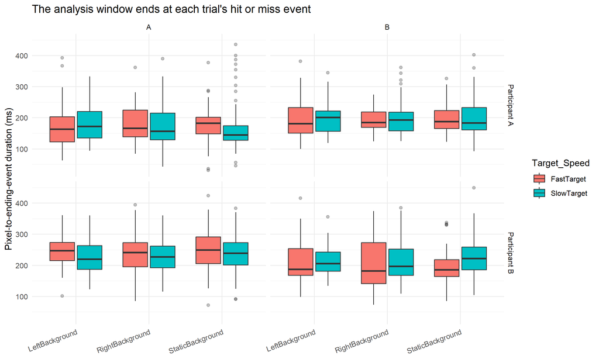

```r
ggplot(filter(trial_audit, Events_OK), aes(Background, End_ms, fill = Target_Speed)) +
  geom_boxplot(outlier.alpha = .3) + facet_grid(Participant ~ Condition) +
  labs(x = NULL, y = "Pixel-to-ending-event duration (ms)",
    title = "The analysis window ends at each trial's hit or miss event") +
  theme(axis.text.x = element_text(angle = 20, hjust = 1))
```

```r
save_table(retention, "retained_trial_counts.csv")
```

## Original EDA: sample trial and movement signals

Original Sections 4–7 and 17 inspect a sample file, its event values, and lateral position, velocity, and acceleration. Event numbers below are stored timestamps, not the row positions where the event columns happen to be populated.

```r
show_table(sample_metadata |> select(File, Rows, Pixel_frame, End_frame, End_ms, Outcome))
```

| File | Rows | Pixel_frame | End_frame | End_ms | Outcome |
| --- | --- | --- | --- | --- | --- |
| data/Participant A/Condition_A_Block_1/Trial1.StaticBackgroundSlowTarget.csv | 3617 | 2512 | 2617 | 105 | Miss |

```r
names(sample_trial)
```

```
 [1] "Frame"                      "Pec"
 [3] "Right_HandX"                "Right_HandY"
 [5] "Right_HandVelX"             "Right_HandVelY"
 [7] "Right_HandAccX"             "Right_HandAccY"
 [9] "Command to move FF"         "Got target"
[11] "Hand in start"              "Hand left start (good)"
[13] "Hand out start (bad)"       "Missed target"
[15] "Pixel event"                "Show hand feedback"
[17] "Target starts moving"       "Time_ms"
[19] "Time_s"                     "Position_smoothed"
[21] "Velocity_from_position"     "Acceleration_from_position"
[23] "Velocity_raw_position"      "Acceleration_raw_position"
[25] "Acceleration_from_velocity" "In_response"
[27] "Trial_ID"                   "Participant"
[29] "Condition"                  "Block"
[31] "Trial"                      "Background"
[33] "Target_Speed"               "Outcome"
[35] "End_ms"                     "Eligible"
```

```r
show_table(sample_trial |> select(all_of(signal_columns)) |> head(6))
```

| Frame | Right_HandX | Right_HandY | Right_HandVelX | Right_HandVelY | Right_HandAccX | Right_HandAccY |
| --- | --- | --- | --- | --- | --- | --- |
| 2212 | 0.2 | 0.13 | 0.02 | 0.27 | -5.00 | 5.05 |
| 2213 | 0.2 | 0.13 | 0.01 | 0.28 | -5.82 | 2.76 |
| 2214 | 0.2 | 0.13 | 0.01 | 0.28 | 2.59 | 0.46 |
| 2215 | 0.2 | 0.13 | 0.02 | 0.28 | 5.88 | 0.06 |
| 2216 | 0.2 | 0.13 | 0.02 | 0.28 | 0.72 | -0.35 |
| 2217 | 0.2 | 0.13 | 0.02 | 0.28 | -3.24 | 2.40 |

```r
summary(sample_trial$Right_HandAccX)
```

```
    Min.  1st Qu.   Median     Mean  3rd Qu.     Max.
-7.75605 -1.39698 -0.02980 -0.02907  1.30385  8.70228
```

```r
show_table(sample_events)
```

| Frame | Command to move FF | Got target | Hand in start | Hand left start (good) | Hand out start (bad) | Missed target | Pixel event | Show hand feedback | Target starts moving |
| --- | --- | --- | --- | --- | --- | --- | --- | --- | --- |
| 0 | 2494;2537 | NA | 0;565 | 2107 | 50 | 2617 | 2512 | 3117 | 1517 |
| 1 | NA | NA | NA | NA | NA | NA | NA | NA | NA |
| 2 | NA | NA | NA | NA | NA | NA | NA | NA | NA |
| 3 | NA | NA | NA | NA | NA | NA | NA | NA | NA |
| 4 | NA | NA | NA | NA | NA | NA | NA | NA | NA |
| 5 | NA | NA | NA | NA | NA | NA | NA | NA | NA |
| 6 | NA | NA | NA | NA | NA | NA | NA | NA | NA |
| 7 | NA | NA | NA | NA | NA | NA | NA | NA | NA |
| 8 | NA | NA | NA | NA | NA | NA | NA | NA | NA |
| 9 | NA | NA | NA | NA | NA | NA | NA | NA | NA |

```r
show_table(sample_events |> select(all_of(event_columns)) |>
  pivot_longer(everything(), names_to = "Event", values_to = "Stored_value") |>
  filter(!is.na(Stored_value), nzchar(Stored_value)) |> distinct())
```

| Event | Stored_value |
| --- | --- |
| Command to move FF | 2494;2537 |
| Hand in start | 0;565 |
| Hand left start (good) | 2107 |
| Hand out start (bad) | 50 |
| Missed target | 2617 |
| Pixel event | 2512 |
| Show hand feedback | 3117 |
| Target starts moving | 1517 |

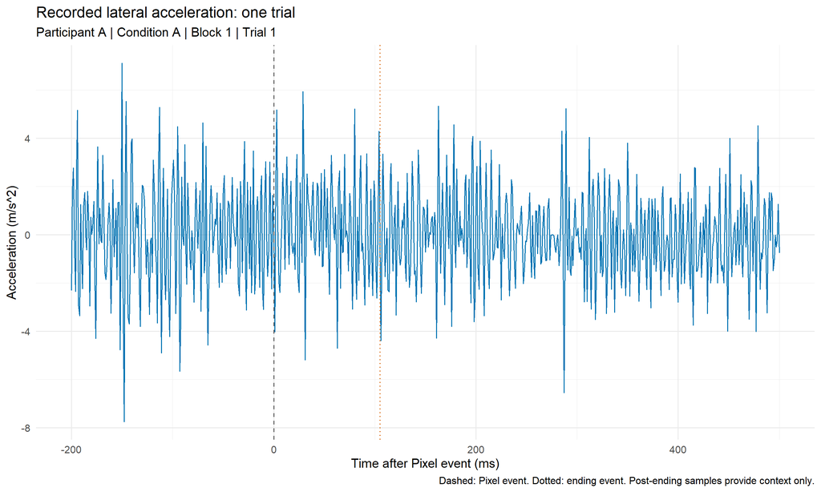

```r
sample_plot_data <- sample_trial |> filter(between(Time_ms, -200, 500))
p_sample <- ggplot(sample_plot_data, aes(Time_ms, Right_HandAccX)) +
  geom_line(color = "#0072B2", linewidth = .4) + event_lines() +
  geom_vline(xintercept = sample_metadata$End_ms, color = "#D55E00", linetype = "dotted") +
  labs(title = "Recorded lateral acceleration: one trial", subtitle = sample_label,
    x = "Time after Pixel event (ms)", y = "Acceleration (m/s^2)",
    caption = "Dashed: Pixel event. Dotted: ending event. Post-ending samples provide context only.")
p_sample
```

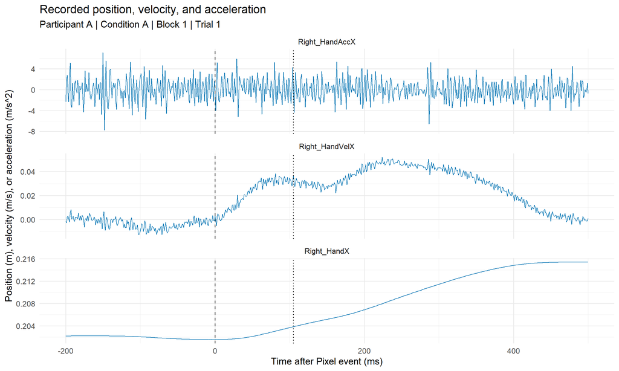

```r
save_figure(p_sample, "sample_recorded_acceleration.png")

sample_plot_data |> select(Time_ms, Right_HandX, Right_HandVelX, Right_HandAccX) |>
  pivot_longer(-Time_ms, names_to = "Measurement", values_to = "Value") |>
  ggplot(aes(Time_ms, Value)) + geom_line(color = "#0072B2", linewidth = .35) +
  event_lines() + geom_vline(xintercept = sample_metadata$End_ms, linetype = "dotted") +
  facet_wrap(~ Measurement, ncol = 1, scales = "free_y") +
  labs(title = "Recorded position, velocity, and acceleration", subtitle = sample_label,
    x = "Time after Pixel event (ms)", y = "Position (m), velocity (m/s), or acceleration (m/s^2)")
```

## Original EDA: selected trial averages and variability

These reproduce the comparisons in original Sections 10–16 and 21–23 using recorded signals, with repeated plot variants consolidated. The first selection is Participant A, Condition A, Block 1, static background, slow target. The last two plots pool all three blocks, as in the original script. These remain **descriptive plots over a fixed window**, including post-outcome context. Static trials remain useful for comparison even if they are ultimately mapped to the excluded “none” onset group. Shading is SD across trials, not a confidence interval or uncertainty across participants.

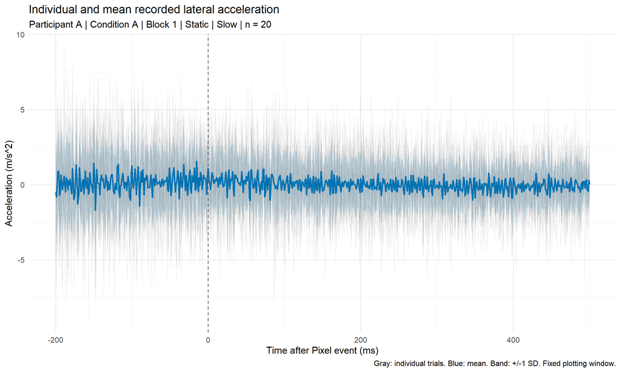

```r
legacy_data <- all_data |> filter(Eligible, Participant == "Participant A",
  Condition == "A", Target_Speed == "SlowTarget", between(Time_ms, -200, 500))
legacy_one_block <- legacy_data |> filter(Block == 1, Background == "StaticBackground")
legacy_summary <- legacy_one_block |> group_by(Time_ms) |>
  summarise(Mean = finite_mean(Right_HandAccX), SD = finite_sd(Right_HandAccX),
    N = sum(is.finite(Right_HandAccX)))
legacy_n <- n_distinct(legacy_one_block$Trial_ID)
p_legacy <- ggplot(legacy_one_block, aes(Time_ms, Right_HandAccX, group = Trial_ID)) +
  geom_line(color = "gray60", alpha = .25, linewidth = .25) +
  geom_ribbon(data = legacy_summary, aes(x = Time_ms, ymin = Mean - SD, ymax = Mean + SD),
    inherit.aes = FALSE, fill = "#0072B2", alpha = .15) +
  geom_line(data = legacy_summary, aes(Time_ms, Mean), inherit.aes = FALSE,
    color = "#0072B2", linewidth = .8) + event_lines() +
  labs(title = "Individual and mean recorded lateral acceleration",
    subtitle = paste("Participant A | Condition A | Block 1 | Static | Slow | n =", legacy_n),
    x = "Time after Pixel event (ms)", y = "Acceleration (m/s^2)",
    caption = "Gray: individual trials. Blue: mean. Band: +/-1 SD. Fixed plotting window.")
p_legacy
```

```r
save_figure(p_legacy, "original_individual_mean_variability.png")
show_table(trial_info |> filter(Participant == "Participant A", Condition == "A",
  Block == 1, Target_Speed == "SlowTarget") |> count(Background))
```

| Background | n |
| --- | --- |
| LeftBackground | 15 |
| RightBackground | 15 |
| StaticBackground | 20 |

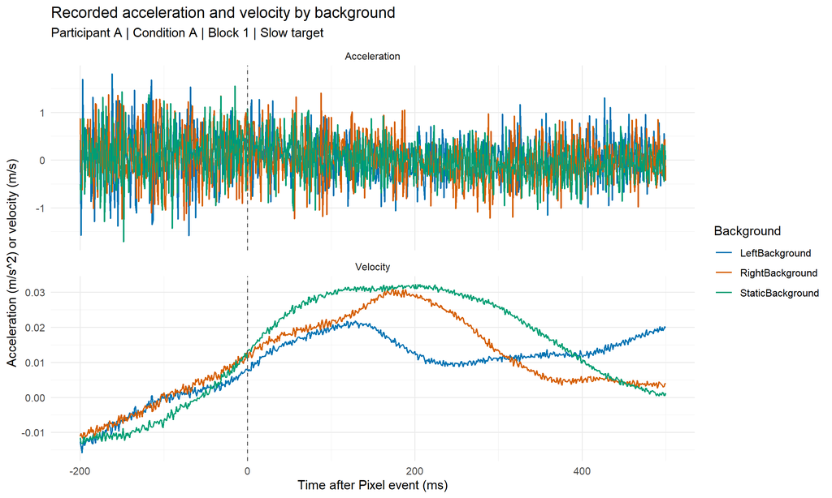

```r
legacy_background <- legacy_data |> filter(Block == 1) |> group_by(Background, Time_ms) |>
  summarise(Acceleration = finite_mean(Right_HandAccX), Velocity = finite_mean(Right_HandVelX))
legacy_background |> pivot_longer(c(Acceleration, Velocity), names_to = "Signal", values_to = "Mean") |>
  ggplot(aes(Time_ms, Mean, color = Background)) + geom_line(linewidth = .6) +
  event_lines() + facet_wrap(~ Signal, ncol = 1, scales = "free_y") +
  scale_color_manual(values = background_colors) +
  labs(title = "Recorded acceleration and velocity by background",
    subtitle = "Participant A | Condition A | Block 1 | Slow target",
    x = "Time after Pixel event (ms)", y = "Acceleration (m/s^2) or velocity (m/s)")
```

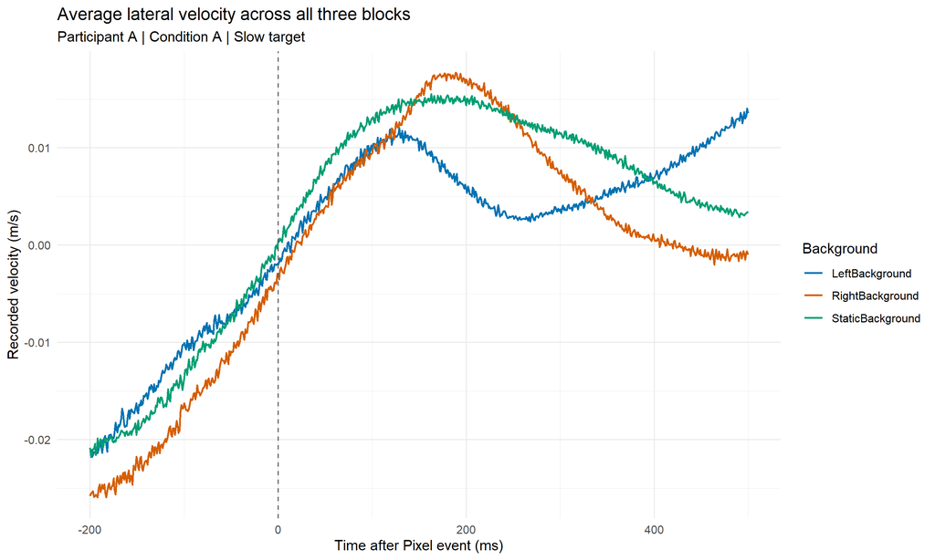

```r
legacy_velocity <- legacy_data |> group_by(Background, Time_ms) |>
  summarise(Mean = finite_mean(Right_HandVelX))
p_velocity <- ggplot(legacy_velocity, aes(Time_ms, Mean, color = Background)) +
  geom_line(linewidth = .7) + event_lines() + scale_color_manual(values = background_colors) +
  labs(title = "Average lateral velocity across all three blocks",
    subtitle = "Participant A | Condition A | Slow target",
    x = "Time after Pixel event (ms)", y = "Recorded velocity (m/s)")
p_velocity
```

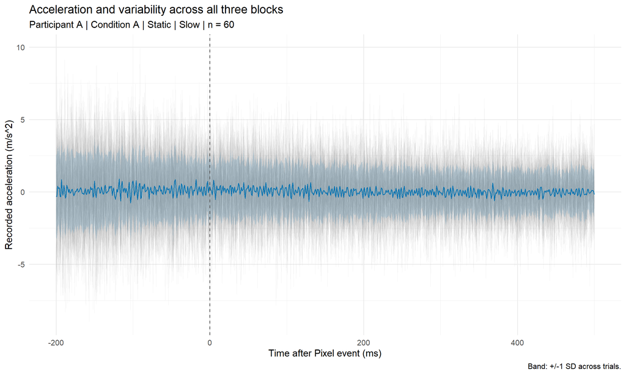

```r
save_figure(p_velocity, "original_all_blocks_velocity.png")

legacy_acceleration <- legacy_data |> filter(Background == "StaticBackground")
legacy_all_summary <- legacy_acceleration |> group_by(Time_ms) |>
  summarise(Mean = finite_mean(Right_HandAccX), SD = finite_sd(Right_HandAccX))
p_all_blocks <- ggplot(legacy_acceleration, aes(Time_ms, Right_HandAccX, group = Trial_ID)) +
  geom_line(alpha = .15, color = "gray60", linewidth = .2) +
  geom_ribbon(data = legacy_all_summary, aes(Time_ms, ymin = Mean - SD, ymax = Mean + SD),
    inherit.aes = FALSE, fill = "#0072B2", alpha = .15) +
  geom_line(data = legacy_all_summary, aes(Time_ms, Mean), inherit.aes = FALSE, color = "#0072B2") +
  event_lines() + labs(title = "Acceleration and variability across all three blocks",
    subtitle = paste("Participant A | Condition A | Static | Slow | n =",
      n_distinct(legacy_acceleration$Trial_ID)), x = "Time after Pixel event (ms)",
    y = "Recorded acceleration (m/s^2)", caption = "Band: +/-1 SD across trials.")
p_all_blocks
```

```r
save_figure(p_all_blocks, "original_all_blocks_acceleration.png")
```

## Original EDA: trial outcomes and hit rates

Original Sections 18–20 are retained here. “Both recorded,” missing outcomes, and failed imports are shown explicitly. Hit rates use all available trials as the denominator, matching the original script; the valid-outcome denominator is also provided so incomplete event records remain visible.

```r
trial_outcomes <- trial_audit |> mutate(Outcome = replace_na(Outcome, "Import failed"))
show_table(trial_outcomes |> count(Outcome) |> mutate(Percentage = 100 * n / sum(n)))
```

| Outcome | n | Percentage |
| --- | --- | --- |
| Hit | 971 | 80.92 |
| Miss | 229 | 19.08 |

```r
show_table(trial_outcomes |> count(Participant, Outcome))
```

| Participant | Outcome | n |
| --- | --- | --- |
| Participant A | Hit | 405 |
| Participant A | Miss | 195 |
| Participant B | Hit | 566 |
| Participant B | Miss | 34 |

```r
hit_rate <- function(d, groups) {
  d |> group_by(across(all_of(groups))) |>
    summarise(Total_trials = n(), Hits = sum(Outcome == "Hit"), Misses = sum(Outcome == "Miss"),
      Other = sum(!Outcome %in% c("Hit", "Miss"))) |>
    mutate(Hit_rate_all = 100 * Hits / Total_trials,
      Hit_rate_valid_outcomes = if_else(Hits + Misses > 0, 100 * Hits / (Hits + Misses), NA_real_))
}
show_table(hit_rate(trial_outcomes, c("Participant", "Condition")))
```

| Participant | Condition | Total_trials | Hits | Misses | Other | Hit_rate_all | Hit_rate_valid_outcomes |
| --- | --- | --- | --- | --- | --- | --- | --- |
| Participant A | A | 300 | 182 | 118 | 0 | 60.67 | 60.67 |
| Participant A | B | 300 | 223 | 77 | 0 | 74.33 | 74.33 |
| Participant B | A | 300 | 288 | 12 | 0 | 96.00 | 96.00 |
| Participant B | B | 300 | 278 | 22 | 0 | 92.67 | 92.67 |

```r
show_table(hit_rate(trial_outcomes, "Target_Speed"))
```

| Target_Speed | Total_trials | Hits | Misses | Other | Hit_rate_all | Hit_rate_valid_outcomes |
| --- | --- | --- | --- | --- | --- | --- |
| FastTarget | 600 | 484 | 116 | 0 | 80.67 | 80.67 |
| SlowTarget | 600 | 487 | 113 | 0 | 81.17 | 81.17 |

```r
show_table(hit_rate(trial_outcomes, c("Participant", "Target_Speed")))
```

| Participant | Target_Speed | Total_trials | Hits | Misses | Other | Hit_rate_all | Hit_rate_valid_outcomes |
| --- | --- | --- | --- | --- | --- | --- | --- |
| Participant A | FastTarget | 300 | 204 | 96 | 0 | 68.00 | 68.00 |
| Participant A | SlowTarget | 300 | 201 | 99 | 0 | 67.00 | 67.00 |
| Participant B | FastTarget | 300 | 280 | 20 | 0 | 93.33 | 93.33 |
| Participant B | SlowTarget | 300 | 286 | 14 | 0 | 95.33 | 95.33 |

```r
outcome_by_cell <- hit_rate(trial_outcomes,
  c("Participant", "Condition", "Block", "Background", "Target_Speed"))
save_table(outcome_by_cell, "outcomes_by_experimental_cell.csv")
```

## Added EDA: validate position-derived acceleration

The original velocity-to-acceleration check is retained, alongside the required position-to-velocity-to-acceleration calculation. Agreement is assessed using correlation **and** signed bias and RMSE; correlation alone cannot detect a scale or offset error. Different derivative conventions can also introduce a sample offset. The supplied signals are comparison measurements, not assumed ground truth. Numerical differentiation amplifies small position fluctuations.

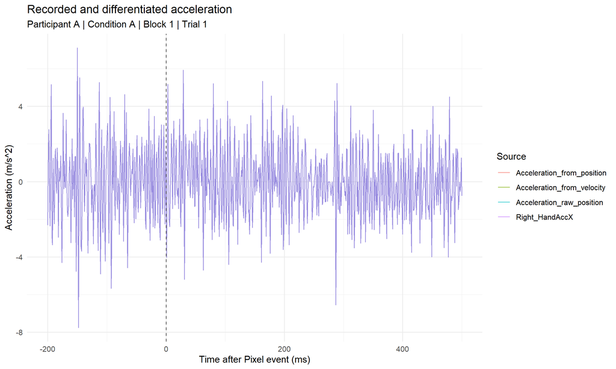

```r
sample_plot_data |> select(Time_ms, Right_HandAccX, Acceleration_from_velocity,
  Acceleration_raw_position, Acceleration_from_position) |>
  pivot_longer(-Time_ms, names_to = "Source", values_to = "Acceleration") |>
  ggplot(aes(Time_ms, Acceleration, color = Source)) + geom_line(alpha = .7, linewidth = .4) +
  event_lines() + labs(title = "Recorded and differentiated acceleration", subtitle = sample_label,
    x = "Time after Pixel event (ms)", y = "Acceleration (m/s^2)")
```

```r
agreement <- response_data |> group_by(Trial_ID) |>
  summarise(
    Correlation = safe_cor(Right_HandAccX, Acceleration_from_position),
    Bias = finite_mean(Acceleration_from_position - Right_HandAccX),
    RMSE = sqrt(finite_mean((Acceleration_from_position - Right_HandAccX)^2)),
    Velocity_RMSE = sqrt(finite_mean((Velocity_from_position - Right_HandVelX)^2)),
    Velocity_derivative_correlation = safe_cor(Right_HandAccX, Acceleration_from_velocity)) |>
  left_join(trial_info |> select(Trial_ID, Participant, Condition, Background, Target_Speed), by = "Trial_ID")
show_table(agreement |> group_by(Participant, Condition) |>
  summarise(Trials = n(), Median_correlation = median(Correlation, na.rm = TRUE),
    Median_bias = median(Bias, na.rm = TRUE), Median_RMSE = median(RMSE, na.rm = TRUE)))
```

| Participant | Condition | Trials | Median_correlation | Median_bias | Median_RMSE |
| --- | --- | --- | --- | --- | --- |
| Participant A | A | 300 | 1 | 0 | 0 |
| Participant A | B | 300 | 1 | 0 | 0 |
| Participant B | A | 300 | 1 | 0 | 0 |
| Participant B | B | 300 | 1 | 0 | 0 |

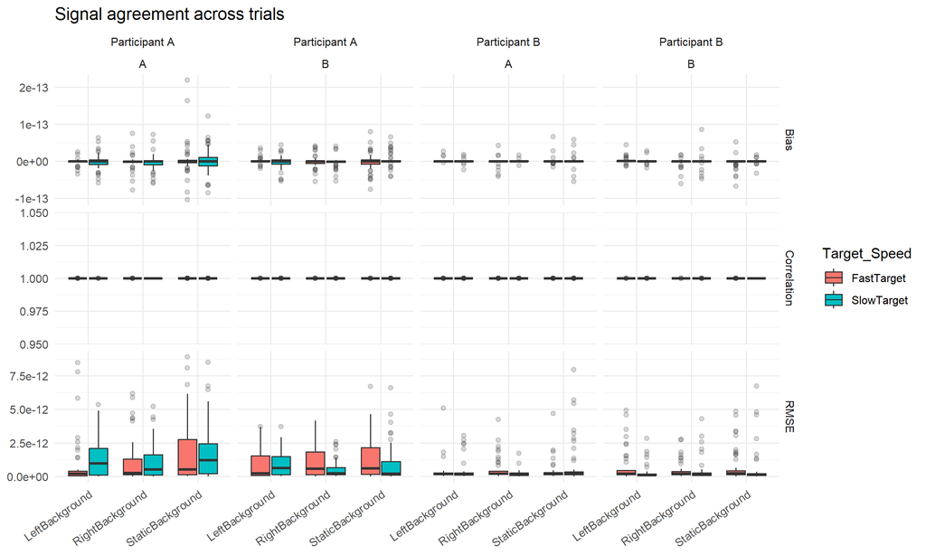

```r
agreement |> pivot_longer(c(Correlation, Bias, RMSE), names_to = "Metric", values_to = "Value") |>
  ggplot(aes(Background, Value, fill = Target_Speed)) + geom_boxplot(outlier.alpha = .2) +
  facet_grid(Metric ~ Participant + Condition, scales = "free_y") +
  labs(title = "Signal agreement across trials", x = NULL, y = NULL) +
  theme(axis.text.x = element_text(angle = 35, hjust = 1))
```

```r
save_table(agreement, "signal_agreement.csv")
```

## Added EDA: all participants, conditions, speeds, and blocks

These plots use position-derived acceleration **only inside valid event windows**, with left/right/static kept separate. They intentionally retain the recorded sign so a proposed direction mapping can be checked visually. The mean at later times may represent fewer and different trials: interpret these curves alongside the contributing-trial counts, rather than treating late changes as changes in the same complete group of trials.

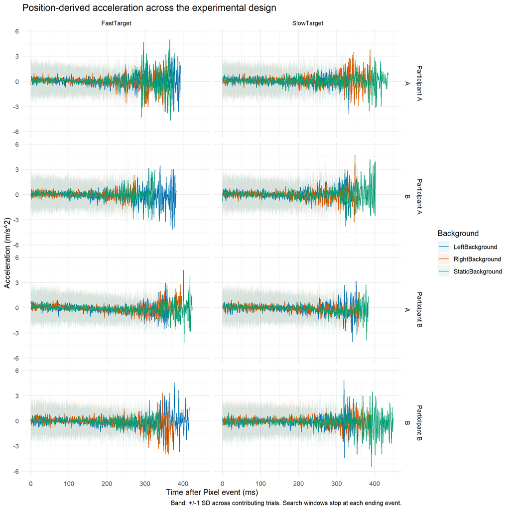

```r
design_summary <- response_data |>
  group_by(Participant, Condition, Background, Target_Speed, Time_ms) |>
  summarise(Mean = finite_mean(Acceleration_from_position), SD = finite_sd(Acceleration_from_position),
    N = sum(is.finite(Acceleration_from_position)))
p_design <- ggplot(design_summary, aes(Time_ms, Mean, color = Background, fill = Background)) +
  geom_ribbon(aes(ymin = Mean - SD, ymax = Mean + SD), alpha = .08, color = NA) +
  geom_line(linewidth = .45) + facet_grid(Participant + Condition ~ Target_Speed) +
  scale_color_manual(values = background_colors) + scale_fill_manual(values = background_colors) +
  labs(title = "Position-derived acceleration across the experimental design",
    x = "Time after Pixel event (ms)", y = "Acceleration (m/s^2)",
    caption = "Band: +/-1 SD across contributing trials. Search windows stop at each ending event.")
p_design
```

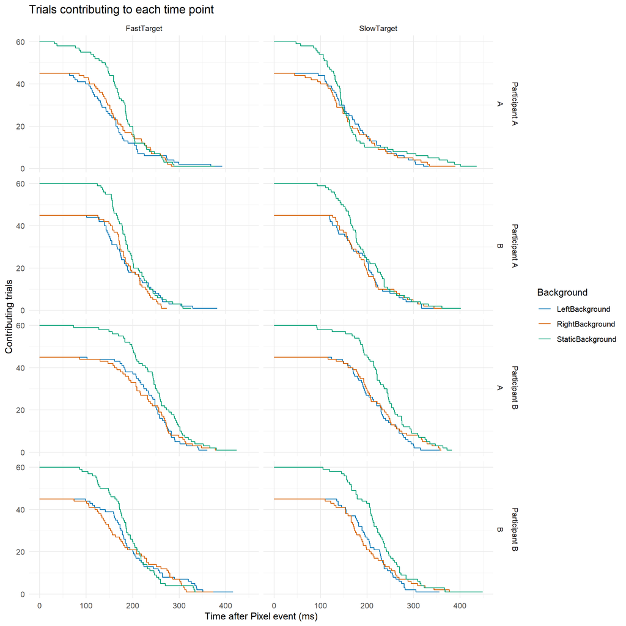

```r
save_figure(p_design, "expanded_design_acceleration.png", height = 10)
ggplot(design_summary, aes(Time_ms, N, color = Background)) + geom_step(linewidth = .5) +
  facet_grid(Participant + Condition ~ Target_Speed) + scale_color_manual(values = background_colors) +
  labs(title = "Trials contributing to each time point", x = "Time after Pixel event (ms)",
    y = "Contributing trials")
```

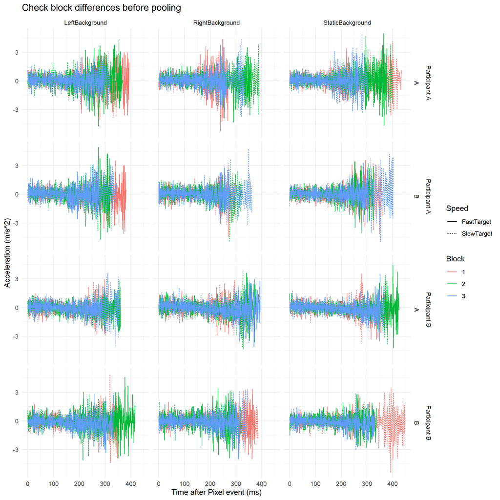

```r
block_summary <- response_data |>
  group_by(Participant, Condition, Block, Background, Target_Speed, Time_ms) |>
  summarise(Mean = finite_mean(Acceleration_from_position), N = n())
ggplot(block_summary, aes(Time_ms, Mean, color = factor(Block), linetype = Target_Speed)) +
  geom_line(linewidth = .4) + facet_grid(Participant + Condition ~ Background) +
  labs(title = "Check block differences before pooling", color = "Block", linetype = "Speed",
    x = "Time after Pixel event (ms)", y = "Acceleration (m/s^2)")
```

## Added EDA: baseline noise, polarity, and threshold feasibility

The baseline is **-200 to -20 ms** relative to the Pixel event. It is a pre-event reference during a reaching task, not necessarily a resting period. Its mean and SD are descriptive; this report does not automatically subtract the mean or replace the project’s absolute thresholds with SD thresholds.

Positive and negative excursions are both reported before the direction mapping is confirmed. The baseline fraction outside +/-threshold is a noise diagnostic, **not** an onset detection rate. A large fraction suggests that a small fixed threshold may be sensitive to signal fluctuations.

```r
baseline <- all_data |> filter(Eligible, between(Time_ms, baseline_limits[1], baseline_limits[2])) |>
  group_by(Trial_ID) |>
  summarise(Baseline_N = sum(is.finite(Acceleration_from_position)),
    Baseline_mean = finite_mean(Acceleration_from_position),
    Baseline_SD = finite_sd(Acceleration_from_position),
    Baseline_RMS = sqrt(finite_mean(Acceleration_from_position^2)),
    Fraction_outside_020 = finite_mean(abs(Acceleration_from_position) >= gmr_threshold),
    Fraction_outside_0125 = finite_mean(abs(Acceleration_from_position) >= alignment_threshold))
peak_features <- response_data |> group_by(Trial_ID) |>
  summarise(
    Positive_peak = finite_max(Acceleration_from_position),
    Negative_peak = finite_min(Acceleration_from_position),
    Absolute_peak = finite_max(abs(Acceleration_from_position)),
    Absolute_peak_ms = Time_ms[which.max(abs(Acceleration_from_position))],
    Response_RMS = sqrt(finite_mean(Acceleration_from_position^2)))
trial_features <- trial_audit |> left_join(baseline, by = "Trial_ID") |>
  left_join(peak_features, by = "Trial_ID") |>
  mutate(Baseline_complete = coalesce(Baseline_N == diff(baseline_limits) + 1, FALSE),
    Peak_near_boundary = Absolute_peak_ms <= 20 | End_ms - Absolute_peak_ms <= 20)
show_table(trial_features |> filter(Eligible) |> group_by(Participant, Condition, Background) |>
  summarise(Trials = n(), Complete_baselines = sum(Baseline_complete),
    Median_baseline_mean = median(Baseline_mean, na.rm = TRUE),
    Median_baseline_SD = median(Baseline_SD, na.rm = TRUE),
    Median_fraction_outside_020 = median(Fraction_outside_020, na.rm = TRUE),
    Median_fraction_outside_0125 = median(Fraction_outside_0125, na.rm = TRUE)))
```

| Participant | Condition | Background | Trials | Complete_baselines | Median_baseline_mean | Median_baseline_SD | Median_fraction_outside_020 | Median_fraction_outside_0125 |
| --- | --- | --- | --- | --- | --- | --- | --- | --- |
| Participant A | A | LeftBackground | 90 | 90 | 0.09 | 2.46 | 0.94 | 0.96 |
| Participant A | A | RightBackground | 90 | 90 | 0.10 | 2.45 | 0.93 | 0.96 |
| Participant A | A | StaticBackground | 120 | 120 | 0.10 | 2.47 | 0.94 | 0.96 |
| Participant A | B | LeftBackground | 90 | 90 | 0.07 | 2.42 | 0.93 | 0.96 |
| Participant A | B | RightBackground | 90 | 90 | 0.08 | 2.40 | 0.94 | 0.96 |
| Participant A | B | StaticBackground | 120 | 120 | 0.10 | 2.45 | 0.93 | 0.96 |
| Participant B | A | LeftBackground | 90 | 90 | 0.06 | 2.50 | 0.94 | 0.96 |
| Participant B | A | RightBackground | 90 | 90 | 0.06 | 2.50 | 0.94 | 0.95 |
| Participant B | A | StaticBackground | 120 | 120 | 0.10 | 2.47 | 0.94 | 0.96 |
| Participant B | B | LeftBackground | 90 | 90 | -0.02 | 2.50 | 0.94 | 0.95 |
| Participant B | B | RightBackground | 90 | 90 | -0.03 | 2.48 | 0.94 | 0.96 |
| Participant B | B | StaticBackground | 120 | 120 | -0.02 | 2.50 | 0.94 | 0.96 |

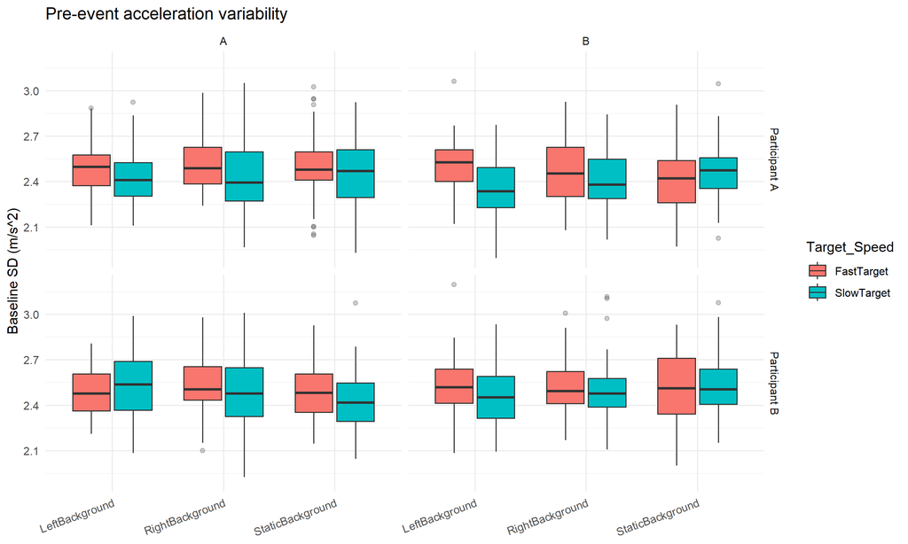

```r
trial_features |> filter(Eligible) |>
  ggplot(aes(Background, Baseline_SD, fill = Target_Speed)) + geom_boxplot(outlier.alpha = .25) +
  facet_grid(Participant ~ Condition) + labs(title = "Pre-event acceleration variability",
    x = NULL, y = "Baseline SD (m/s^2)") + theme(axis.text.x = element_text(angle = 20, hjust = 1))
```

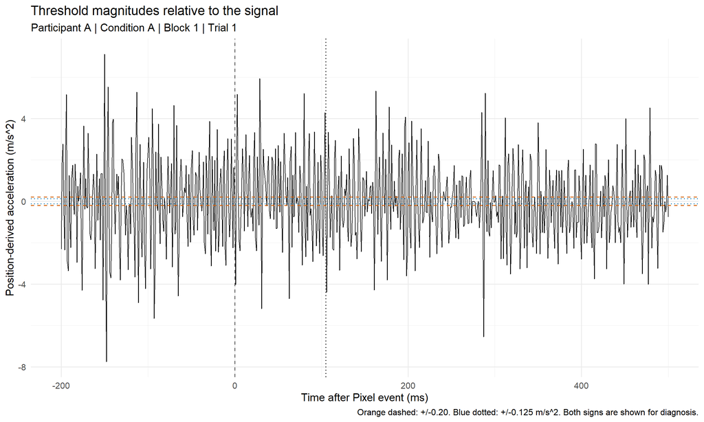

```r
sample_plot_data |> select(Time_ms, Acceleration_from_position) |>
  ggplot(aes(Time_ms, Acceleration_from_position)) + geom_line(linewidth = .35) +
  geom_hline(yintercept = c(-gmr_threshold, gmr_threshold), color = "#D55E00", linetype = "dashed") +
  geom_hline(yintercept = c(-alignment_threshold, alignment_threshold), color = "#0072B2", linetype = "dotted") +
  event_lines() + geom_vline(xintercept = sample_metadata$End_ms, linetype = "dotted") +
  labs(title = "Threshold magnitudes relative to the signal", subtitle = sample_label,
    x = "Time after Pixel event (ms)", y = "Position-derived acceleration (m/s^2)",
    caption = "Orange dashed: +/-0.20. Blue dotted: +/-0.125 m/s^2. Both signs are shown for diagnosis.")
```

```r
save_table(trial_features, "trial_features.csv")
```

### Smoothing sensitivity on a balanced set of example trials

One reproducible trial from each participant × condition × background × speed cell is selected by trial ID. Centered moving averages of **position** are compared at 1, 11, and 21 ms before differentiation. A centered average does not introduce a simple one-way delay, but it can spread post-event information backward and alter onset. These panels illustrate sensitivity, not a validated filter recommendation or a reason to force threshold detection.

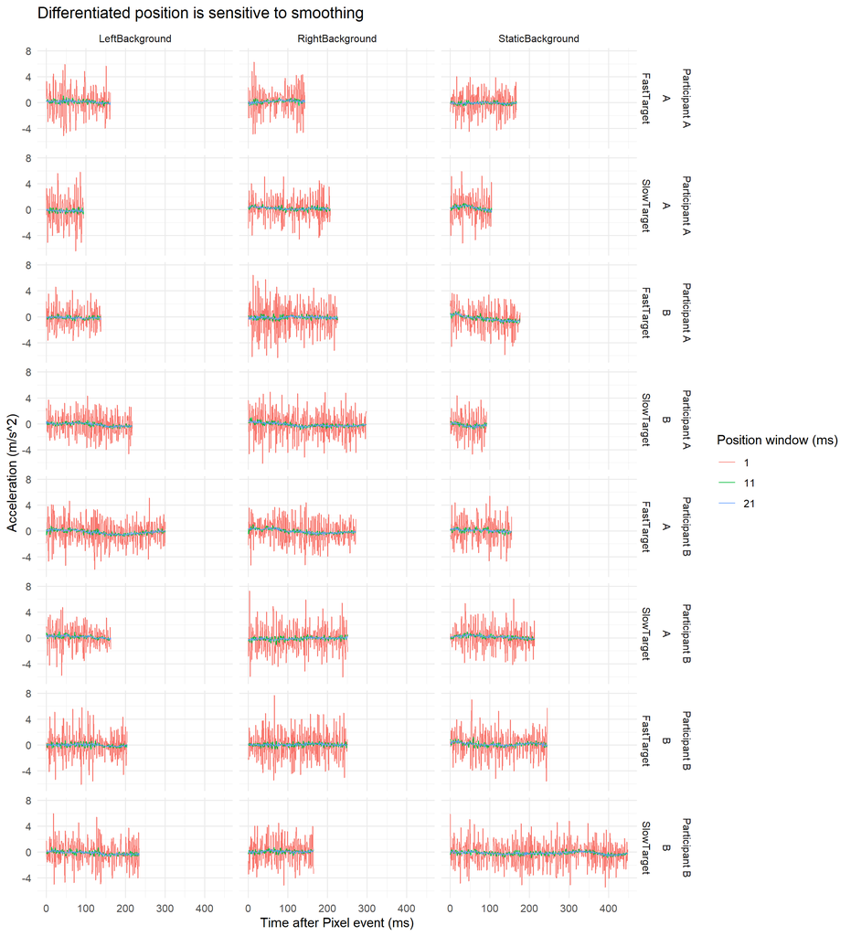

```r
example_ids <- trial_audit |> filter(Eligible) |>
  group_by(Participant, Condition, Background, Target_Speed) |> slice_min(Trial, n = 1, with_ties = FALSE) |>
  ungroup() |> pull(Trial_ID)
sensitivity <- all_data |> filter(Trial_ID %in% example_ids) |> group_by(Trial_ID) |>
  group_modify(~ map_dfr(c(1L, 11L, 21L), function(width) {
    tibble(Time_ms = .x$Time_ms,
      Acceleration = differentiate(differentiate(center_mean(.x$Right_HandX, width), .x$Time_s), .x$Time_s),
      Width_ms = factor(width), In_response = .x$In_response)
  })) |> ungroup() |>
  left_join(trial_info |> select(Trial_ID, Participant, Condition, Background, Target_Speed), by = "Trial_ID")
ggplot(filter(sensitivity, In_response), aes(Time_ms, Acceleration, color = Width_ms)) +
  geom_line(linewidth = .35) + facet_grid(Participant + Condition + Target_Speed ~ Background) +
  labs(title = "Differentiated position is sensitive to smoothing", color = "Position window (ms)",
    x = "Time after Pixel event (ms)", y = "Acceleration (m/s^2)")
```

## Added EDA: trial-level distributions, unusual trials, and outcomes

Peak features here use the **largest absolute signed-signal excursion** as a direction-neutral screening measure. That is different from the relevant positive response peak needed for onset after confirming the response signs. A boundary peak flags a trial for inspection rather than automatically excluding it. Retain participant-level distinctions: repeated trials from two participants do not establish population-level precision.

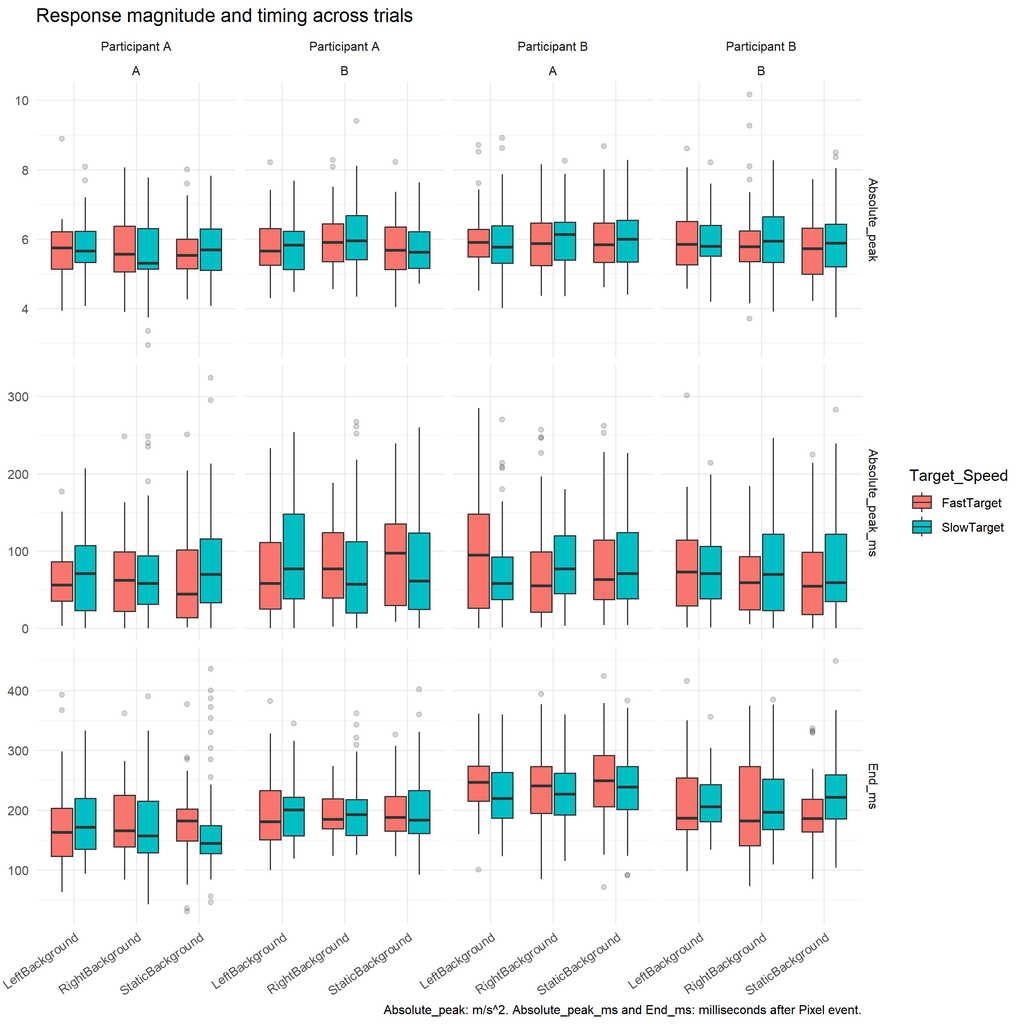

```r
trial_features |> filter(Eligible) |>
  select(Participant, Condition, Background, Target_Speed, Absolute_peak, Absolute_peak_ms, End_ms) |>
  pivot_longer(c(Absolute_peak, Absolute_peak_ms, End_ms), names_to = "Feature", values_to = "Value") |>
  ggplot(aes(Background, Value, fill = Target_Speed)) + geom_boxplot(outlier.alpha = .2) +
  facet_grid(Feature ~ Participant + Condition, scales = "free_y") +
  labs(title = "Response magnitude and timing across trials", x = NULL, y = NULL,
    caption = "Absolute_peak: m/s^2. Absolute_peak_ms and End_ms: milliseconds after Pixel event.") +
  theme(axis.text.x = element_text(angle = 35, hjust = 1))
```

```r
show_table(trial_features |> filter(Eligible) |> group_by(Participant, Condition, Background) |>
  summarise(Trials = n(), Boundary_peaks = sum(Peak_near_boundary, na.rm = TRUE)))
```

| Participant | Condition | Background | Trials | Boundary_peaks |
| --- | --- | --- | --- | --- |
| Participant A | A | LeftBackground | 90 | 22 |
| Participant A | A | RightBackground | 90 | 28 |
| Participant A | A | StaticBackground | 120 | 39 |
| Participant A | B | LeftBackground | 90 | 23 |
| Participant A | B | RightBackground | 90 | 25 |
| Participant A | B | StaticBackground | 120 | 28 |
| Participant B | A | LeftBackground | 90 | 15 |
| Participant B | A | RightBackground | 90 | 19 |
| Participant B | A | StaticBackground | 120 | 25 |
| Participant B | B | LeftBackground | 90 | 24 |
| Participant B | B | RightBackground | 90 | 20 |
| Participant B | B | StaticBackground | 120 | 34 |

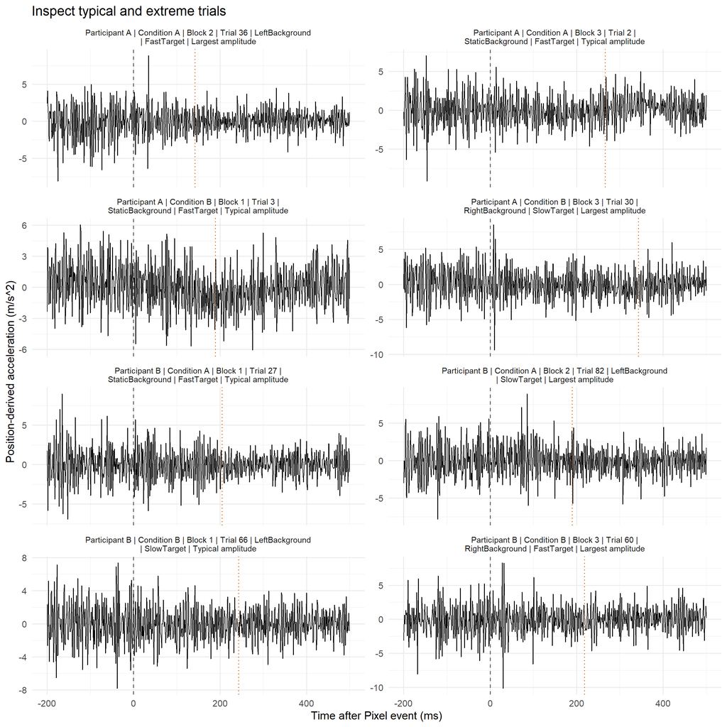

```r
inspection_ids <- trial_features |> filter(Eligible) |> group_by(Participant, Condition) |>
  group_modify(~ {
    typical <- .x |> arrange(abs(Absolute_peak - median(Absolute_peak, na.rm = TRUE))) |> slice_head(n = 1)
    extreme <- .x |> arrange(desc(Absolute_peak)) |> slice_head(n = 1)
    bind_rows(mutate(typical, Example = "Typical amplitude"), mutate(extreme, Example = "Largest amplitude"))
  }) |> ungroup() |> select(Trial_ID, Example)
all_data |> inner_join(inspection_ids, by = "Trial_ID") |> filter(between(Time_ms, -200, 500)) |>
  mutate(Inspection_label = str_wrap(paste(Participant, paste("Condition", Condition),
    paste("Block", Block), paste("Trial", Trial), Background, Target_Speed, Example, sep = " | "), width = 65)) |>
  ggplot(aes(Time_ms, Acceleration_from_position)) + geom_line(linewidth = .3) + event_lines() +
  geom_vline(aes(xintercept = End_ms), linetype = "dotted", color = "#D55E00") +
  facet_wrap(~ Inspection_label, scales = "free_y", ncol = 2) +
  theme(strip.text = element_text(size = 8)) +
  labs(title = "Inspect typical and extreme trials", x = "Time after Pixel event (ms)",
    y = "Position-derived acceleration (m/s^2)")
```

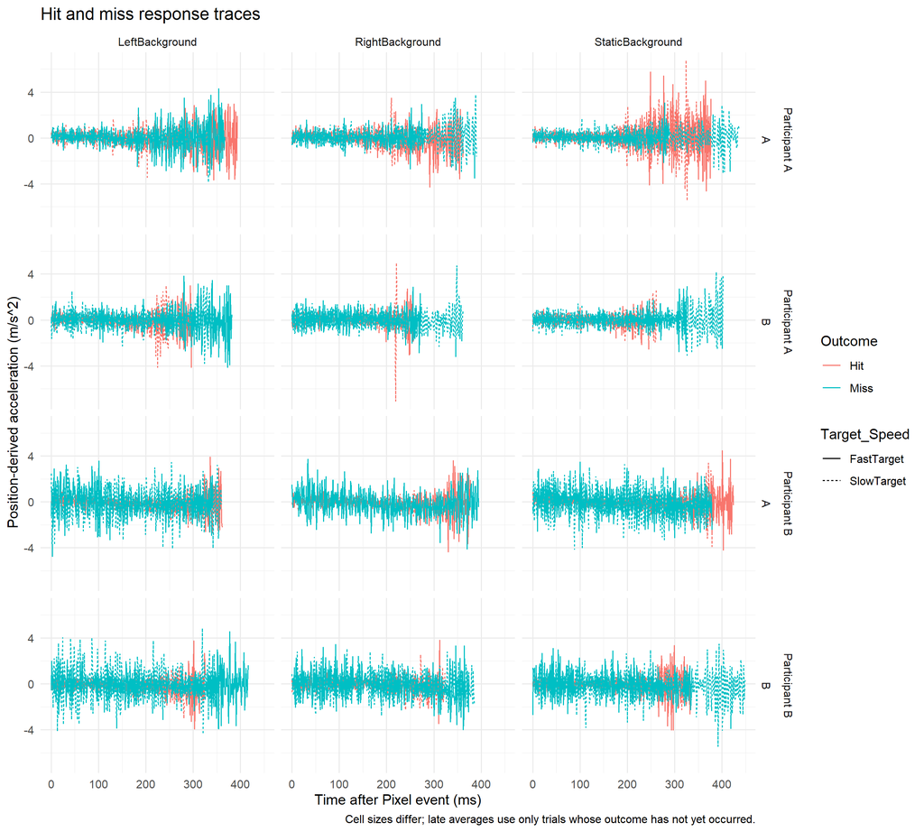

```r
outcome_curves <- response_data |> filter(Outcome %in% c("Hit", "Miss")) |>
  group_by(Participant, Condition, Background, Target_Speed, Outcome, Time_ms) |>
  summarise(Mean = finite_mean(Acceleration_from_position), N = n())
ggplot(outcome_curves, aes(Time_ms, Mean, color = Outcome, linetype = Target_Speed)) +
  geom_line(linewidth = .45) + facet_grid(Participant + Condition ~ Background) +
  labs(title = "Hit and miss response traces", x = "Time after Pixel event (ms)",
    y = "Position-derived acceleration (m/s^2)",
    caption = "Cell sizes differ; late averages use only trials whose outcome has not yet occurred.")
```

```r
show_table(trial_features |> filter(Eligible, Outcome %in% c("Hit", "Miss")) |>
  group_by(Participant, Condition, Target_Speed, Outcome) |>
  summarise(N = n(), Median_peak = median(Absolute_peak),
    Median_peak_ms = median(Absolute_peak_ms), Median_duration_ms = median(End_ms)))
```

| Participant | Condition | Target_Speed | Outcome | N | Median_peak | Median_peak_ms | Median_duration_ms |
| --- | --- | --- | --- | --- | --- | --- | --- |
| Participant A | A | FastTarget | Hit | 94 | 5.49 | 53.5 | 166.5 |
| Participant A | A | FastTarget | Miss | 56 | 5.67 | 55.5 | 173.0 |
| Participant A | A | SlowTarget | Hit | 88 | 5.79 | 55.0 | 145.5 |
| Participant A | A | SlowTarget | Miss | 62 | 5.42 | 85.5 | 212.0 |
| Participant A | B | FastTarget | Hit | 110 | 5.81 | 75.0 | 176.5 |
| Participant A | B | FastTarget | Miss | 40 | 5.63 | 95.5 | 236.5 |
| Participant A | B | SlowTarget | Hit | 113 | 5.74 | 62.0 | 175.0 |
| Participant A | B | SlowTarget | Miss | 37 | 5.65 | 99.0 | 278.0 |
| Participant B | A | FastTarget | Hit | 142 | 5.88 | 62.5 | 247.0 |
| Participant B | A | FastTarget | Miss | 8 | 5.40 | 118.5 | 344.0 |
| Participant B | A | SlowTarget | Hit | 146 | 5.97 | 72.0 | 227.5 |
| Participant B | A | SlowTarget | Miss | 4 | 6.06 | 56.5 | 361.0 |
| Participant B | B | FastTarget | Hit | 138 | 5.80 | 60.5 | 183.5 |
| Participant B | B | FastTarget | Miss | 12 | 5.64 | 42.5 | 334.5 |
| Participant B | B | SlowTarget | Hit | 140 | 5.83 | 66.5 | 207.5 |
| Participant B | B | SlowTarget | Miss | 10 | 6.17 | 78.0 | 361.0 |

## Optional onset analysis: ordinary and threshold-aligned GMR

This section implements the procedures in the project README rather than treating threshold crossing itself as onset. It is disabled until the proposed mapping and coordinate signs are confirmed. Edit the table below if needed. “None” trials stay in EDA but do not enter either onset method.

Participant × condition × direction × speed groups are kept separate before any participant summary, with blocks pooled only at this stage. The participant summary uses equal weights across available groups for ordinary GMR and equal weights across valid trial onsets for threshold-aligned GMR; it reports coverage so these two aggregation choices are explicit. Confirm the intended condition and speed pooling for the final project analysis.

For each peak search, only the trial’s event window is used. The **last upward crossing before the relevant positive peak** is found, with linear interpolation between adjacent samples. Because the README does not specify an additional physiological peak-selection rule, the largest positive peak is the candidate; its validity still needs visual review. Absolute values are not used to turn negative noise into a positive response.

Ordinary GMR fits +/-20 ms around the mean-trace 0.20 m/s^2 crossing. Threshold- aligned GMR uses each trial’s 0.125 m/s^2 crossing, averages on a shared 1 ms grid, and fits -20 to +20 ms about the shared alignment point. No interpolation or regression window is allowed outside the valid event window. Incomplete windows, absent crossings, nonpositive slopes, implausible extrapolations, or incomplete trial contribution to the fit are flagged rather than forced. This stricter complete-window rule is reported as a coverage limitation.

```r
direction_map <- tribble(
  ~Background, ~Direction, ~Response_sign,
  "LeftBackground", "Left", as.numeric(params$left_response_sign),
  "RightBackground", "Right", as.numeric(params$right_response_sign),
  "StaticBackground", "None", NA_real_
)
show_table(direction_map)
```

| Background | Direction | Response_sign |
| --- | --- | --- |
| LeftBackground | Left | -1 |
| RightBackground | Right | 1 |
| StaticBackground | None | NA |

```r
group_columns <- c("Participant", "Condition", "Direction", "Target_Speed")

last_crossing <- function(time, acceleration, threshold) {
  ok <- is.finite(time) & is.finite(acceleration)
  t <- time[ok]; a <- acceleration[ok]
  if (length(a) < 3 || max(a) <= threshold) {
    return(list(Status = "No positive peak above threshold", Crossing = NA_real_, Peak_ms = NA_real_))
  }
  peak <- which.max(a)
  if (peak <= 1) return(list(Status = "Peak at window start", Crossing = NA_real_, Peak_ms = t[peak]))
  candidates <- which(head(a, -1) < threshold & tail(a, -1) >= threshold &
                        seq_len(length(a) - 1) < peak & diff(t) <= 1.001)
  if (!length(candidates)) return(list(Status = "No valid upward crossing before peak",
                                      Crossing = NA_real_, Peak_ms = t[peak]))
  j <- tail(candidates, 1)
  crossing <- t[j] + (threshold - a[j]) * (t[j + 1] - t[j]) / (a[j + 1] - a[j])
  list(Status = "OK", Crossing = crossing, Peak_ms = t[peak])
}
fit_onset_line <- function(time, acceleration, center) {
  grid <- center + seq(-fit_half_width, fit_half_width, by = 1)
  if (length(time) < 3 || min(grid) < min(time) || max(grid) > max(time)) {
    return(list(Status = "Incomplete 41 ms regression window"))
  }
  y <- approx(time, acceleration, xout = grid, rule = 1)$y
  if (any(!is.finite(y))) return(list(Status = "Missing regression samples"))
  fit <- lm(y ~ grid)
  intercept <- unname(coef(fit)[1]); slope <- unname(coef(fit)[2])
  onset <- -intercept / slope
  if (!is.finite(slope) || slope <= 0 || !is.finite(onset) || onset > center) {
    return(list(Status = "Invalid rising-line extrapolation"))
  }
  list(Status = "OK", Slope = slope, Intercept = intercept, Onset = onset,
       R_squared = summary(fit)$r.squared)
}
run_gmr <- function(d) {
  curve <- d |> group_by(Time_ms) |> summarise(Mean = mean(Response), N = n_distinct(Trial_ID))
  crossing <- last_crossing(curve$Time_ms, curve$Mean, gmr_threshold)
  result <- tibble(Method = "Ordinary GMR", Status = crossing$Status,
    Trials = n_distinct(d$Trial_ID), Valid_trials = 0L, Crossing_ms = crossing$Crossing,
    Peak_ms = crossing$Peak_ms, Onset_ms = NA_real_, Slope = NA_real_,
    Intercept = NA_real_, R_squared = NA_real_)
  if (crossing$Status != "OK") return(list(result = result, curve = curve))
  fit <- fit_onset_line(curve$Time_ms, curve$Mean, crossing$Crossing)
  result$Status <- fit$Status
  required <- curve |> filter(abs(Time_ms - crossing$Crossing) <= fit_half_width + 1)
  if (fit$Status == "OK" && any(required$N != result$Trials)) {
    result$Status <- "Changing trial contribution in regression window"
  }
  if (result$Status == "OK" && fit$Onset < 0) result$Status <- "Estimated onset before Pixel event"
  if (result$Status == "OK") {
    result$Onset_ms <- fit$Onset; result$Slope <- fit$Slope; result$Intercept <- fit$Intercept
    result$R_squared <- fit$R_squared; result$Valid_trials <- result$Trials
  }
  list(result = result, curve = curve)
}
run_threshold_gmr <- function(d) {
  trials <- d |> group_by(Trial_ID) |> group_split()
  crossings <- map_dfr(trials, function(trial) {
    crossing <- last_crossing(trial$Time_ms, trial$Response, alignment_threshold)
    status <- crossing$Status
    if (status == "OK" && (crossing$Crossing - fit_half_width < min(trial$Time_ms) ||
        crossing$Crossing + fit_half_width > max(trial$Time_ms))) {
      status <- "Incomplete 41 ms alignment window"
    }
    tibble(Trial_ID = trial$Trial_ID[1], Crossing_ms = crossing$Crossing,
      Peak_ms = crossing$Peak_ms, Status = status)
  })
  crossings <- crossings |> mutate(Shared_delay_ms = NA_real_, Onset_ms = NA_real_)
  valid <- crossings |> filter(Status == "OK")
  result <- tibble(Method = "Threshold-aligned GMR", Status = "No valid alignment trials",
    Trials = length(trials), Valid_trials = 0L, Alignment_trials = nrow(valid), Crossing_ms = NA_real_,
    Peak_ms = NA_real_, Onset_ms = NA_real_, Slope = NA_real_, Intercept = NA_real_,
    R_squared = NA_real_, Shared_delay_ms = NA_real_)
  if (!nrow(valid)) return(list(result = result, curve = tibble(), trials = crossings))
  # Shift by the saved crossing, not by a rounded approximation to it.
  aligned <- map_dfr(trials, function(trial) {
    cross <- valid$Crossing_ms[match(trial$Trial_ID[1], valid$Trial_ID)]
    if (!length(cross) || !is.finite(cross)) return(tibble())
    grid <- seq(ceiling(min(trial$Time_ms) - cross), floor(max(trial$Time_ms) - cross), by = 1)
    tibble(Trial_ID = trial$Trial_ID[1], Time_ms = grid,
      Response = approx(trial$Time_ms - cross, trial$Response, xout = grid, rule = 1)$y)
  })
  curve <- aligned |> group_by(Time_ms) |>
    summarise(Mean = finite_mean(Response), N = sum(is.finite(Response)))
  fit <- fit_onset_line(curve$Time_ms, curve$Mean, 0)
  result$Status <- fit$Status
  if (fit$Status == "OK" && any(curve$N[abs(curve$Time_ms) <= fit_half_width] != nrow(valid))) {
    result$Status <- "Incomplete aligned regression contribution"
  }
  if (result$Status == "OK") {
    delay <- -fit$Onset
    crossings <- crossings |> mutate(Shared_delay_ms = delay,
      Onset_ms = if_else(Status == "OK", Crossing_ms - delay, NA_real_),
      Status = if_else(Status == "OK" & Onset_ms < 0, "Estimated onset before Pixel event", Status),
      Onset_ms = if_else(Status == "OK", Onset_ms, NA_real_))
    result$Onset_ms <- finite_mean(crossings$Onset_ms)
    result$Valid_trials <- sum(is.finite(crossings$Onset_ms))
    result$Crossing_ms <- finite_mean(crossings$Crossing_ms[is.finite(crossings$Onset_ms)])
    result$Slope <- fit$Slope; result$Intercept <- fit$Intercept
    result$R_squared <- fit$R_squared; result$Shared_delay_ms <- delay
    if (!result$Valid_trials) result$Status <- "No valid post-Pixel trial onsets"
  } else {
    crossings <- crossings |> mutate(Status = if_else(Status == "OK", result$Status, Status))
  }
  list(result = result, curve = curve, trials = crossings)
}
```

```r
if (!isTRUE(params$mapping_confirmed)) {
  cat("**Onset estimation was not run:** confirm the direction mapping and coordinate signs, then set `mapping_confirmed: true`. All EDA above runs independently.\n")
} else {
  onset_data <- response_data |> left_join(direction_map, by = "Background") |>
    filter(Direction != "None", is.finite(Response_sign)) |>
    mutate(Response = Acceleration_from_position * Response_sign)
  grouped <- onset_data |> group_by(across(all_of(group_columns))) |> group_nest()
  if (!nrow(grouped)) stop("No eligible directional onset groups.")
  grouped <- grouped |> mutate(Ordinary = map(data, run_gmr), Aligned = map(data, run_threshold_gmr))
  method_results <- map_dfr(seq_len(nrow(grouped)), function(i) {
    bind_cols(grouped[rep(i, 2), group_columns],
      bind_rows(grouped$Ordinary[[i]]$result, grouped$Aligned[[i]]$result))
  })
  trial_onsets <- map_dfr(seq_len(nrow(grouped)), function(i) {
    bind_cols(grouped[rep(i, nrow(grouped$Aligned[[i]]$trials)), group_columns], grouped$Aligned[[i]]$trials)
  })
  print(show_table(method_results))
  cat("\n\nTrial-level threshold-alignment status:\n\n")
  print(show_table(trial_onsets |> count(Participant, Condition, Direction, Target_Speed, Status)))
  diagnostic_curves <- map_dfr(seq_len(nrow(grouped)), function(i) {
    map2_dfr(c("Ordinary", "Aligned"), c("Ordinary GMR", "Threshold-aligned GMR"), function(slot, method) {
      curve <- grouped[[slot]][[i]]$curve
      if (!nrow(curve)) return(tibble())
      bind_cols(grouped[rep(i, nrow(curve)), group_columns], curve) |> mutate(Method = method)
    })
  })
  diagnostic_lines <- method_results |> filter(Status == "OK") |>
    mutate(Plot_crossing = if_else(Method == "Ordinary GMR", Crossing_ms, 0),
      Plot_onset = if_else(Method == "Ordinary GMR", Onset_ms, -Shared_delay_ms),
      Threshold = if_else(Method == "Ordinary GMR", gmr_threshold, alignment_threshold))
  for (method in c("Ordinary GMR", "Threshold-aligned GMR")) {
    curves <- diagnostic_curves |> filter(Method == method)
    lines <- diagnostic_lines |> filter(Method == method)
    if (!nrow(curves)) next
    p <- ggplot(curves, aes(Time_ms, Mean)) + geom_line(linewidth = .45) +
      geom_hline(yintercept = 0, color = "gray70") +
      geom_hline(yintercept = if (method == "Ordinary GMR") gmr_threshold else alignment_threshold,
        color = "#D55E00", linetype = "dotted") +
      geom_segment(data = lines, aes(x = Plot_onset, y = 0,
        xend = Plot_crossing + fit_half_width,
        yend = Intercept + Slope * (Plot_crossing + fit_half_width)),
        inherit.aes = FALSE, color = "#0072B2") +
      geom_vline(data = lines, aes(xintercept = Plot_crossing), linetype = "dashed", color = "#D55E00") +
      geom_vline(data = lines, aes(xintercept = Plot_onset), linetype = "dashed", color = "#009E73") +
      facet_grid(Participant + Condition ~ Direction + Target_Speed) +
      labs(title = paste(method, "diagnostics"),
        x = if (method == "Ordinary GMR") "Time after Pixel event (ms)" else "Time after threshold alignment (ms)",
        y = "Direction-consistent acceleration (m/s^2)",
        caption = "Orange: threshold/crossing. Blue: fitted line. Green: estimated zero intercept. See status table for flagged groups.")
    print(p)
    save_figure(p, paste0(if (method == "Ordinary GMR") "gmr" else "threshold_aligned_gmr", "_diagnostics.png"), height = 10)
  }
  participant_summary <- method_results |> group_by(Participant, Method) |>
    summarise(Groups_available = n(), Groups_valid = sum(Status == "OK"),
      Trials_valid = sum(Valid_trials),
      Mean_onset_ms = if (first(Method) == "Ordinary GMR") finite_mean(Onset_ms) else {
        ok <- is.finite(Onset_ms) & Valid_trials > 0
        if (any(ok)) weighted.mean(Onset_ms[ok], Valid_trials[ok]) else NA_real_
      })
  cat("\n\nParticipant summaries (descriptive; inspect coverage and group differences):\n\n")
  print(show_table(participant_summary))
  save_table(method_results, "onset_group_results.csv")
  save_table(trial_onsets, "threshold_aligned_trial_onsets.csv")
  save_table(participant_summary, "participant_onset_summary.csv")
}
```

**Onset estimation was not run:** confirm the direction mapping and coordinate signs, then set `mapping_confirmed: true`. All EDA above runs independently.

## What to review before reporting final onset results

1. Confirm left/right/none labels, acceleration signs, and the meaning of Conditions A/B.
2. Inspect event-duration distributions, signal agreement, baseline variability, and candidate peak shapes. Check whether a short response window actually contains the intended correction response.
3. Document any filtering decision and examine onset sensitivity rather than choosing smoothing to obtain a preferred answer.
4. Review block, condition, and speed differences before accepting a pooled participant summary. Report exclusions and valid-group coverage with onset.
5. Keep trial variability distinct from uncertainty across people. This dataset contains two participants; no population-level inferential claims are made here.

## Original-script coverage

| Original sections | Location in this report |
| --- | --- |
| 1–3: packages, paths, file discovery | Setup; file inventory |
| 4–7: sample, events, acceleration, position/velocity | Sample trial and movement signals |
| 8–9, 13: organization, metadata, background counts | File inventory; selected trial averages |
| 10–12: alignment, individual/mean traces, SD | Selected trial averages and variability |
| 14–16: background acceleration/velocity, derivative check | Selected averages; validate position-derived acceleration |
| 17–20: events, outcomes, participant/condition/speed hit rates | Sample events; trial outcomes and hit rates |
| 21–23: all-block velocity and acceleration, SD | Selected trial averages and variability |

## Reproducibility

Render this file from the project folder using Quarto’s **Render** button or `quarto render 02_exploratory_analysis.qmd`. Required R packages are `tidyverse`, `knitr`, and `rmarkdown`. The HTML includes expandable code. With `export_results: true`, audit tables, feature tables, and selected figures are saved in `eda_output/`; the original `figures/` outputs are preserved.

The method constants above come from the supplied `working_projectREADME.pdf`: 0.20 m/s^2 ordinary GMR, 0.125 m/s^2 threshold alignment, and a +/-20 ms linear-fit window. The README remains the project specification; the optional mapping, filtering, grouping, and complete-window rules are explicitly identified here as analysis choices requiring review.